# Marvin the Robot Experiments

Jenna Register

November, 2016

# Experiment One

Experiment One tests for consistent responses for 1-example abstract relations with novel objects. Participants see the three specified arguments in the form of (f x) = y. They are then asked to generalize to the various questions and respond with one of the **n + 1** objects they have already seen.

#### Do people provide structured generalizations for these abstract relations?

### Pre-processing data

```r
library(ggplot2)


# We decided to change things after the pilot, so the first 10 people from the pilot have to be discarded.
#data=data[-c(1:90),]
#if a worker responded way too fast, drop 'em!
#fail = data$WorkerID[data$RT<1000]
#we don't really want to see this column
#data=data[data$Argument1!=" Reason",]

# exclude workers who failed the check
#data=data[!(data$WorkerID %in% fail),]
#data=droplevels(data)
#anaonymize data (this is already done for the file you have)
#data$WorkerID=as.numeric(data$WorkerID)
```

### Plotting the responses

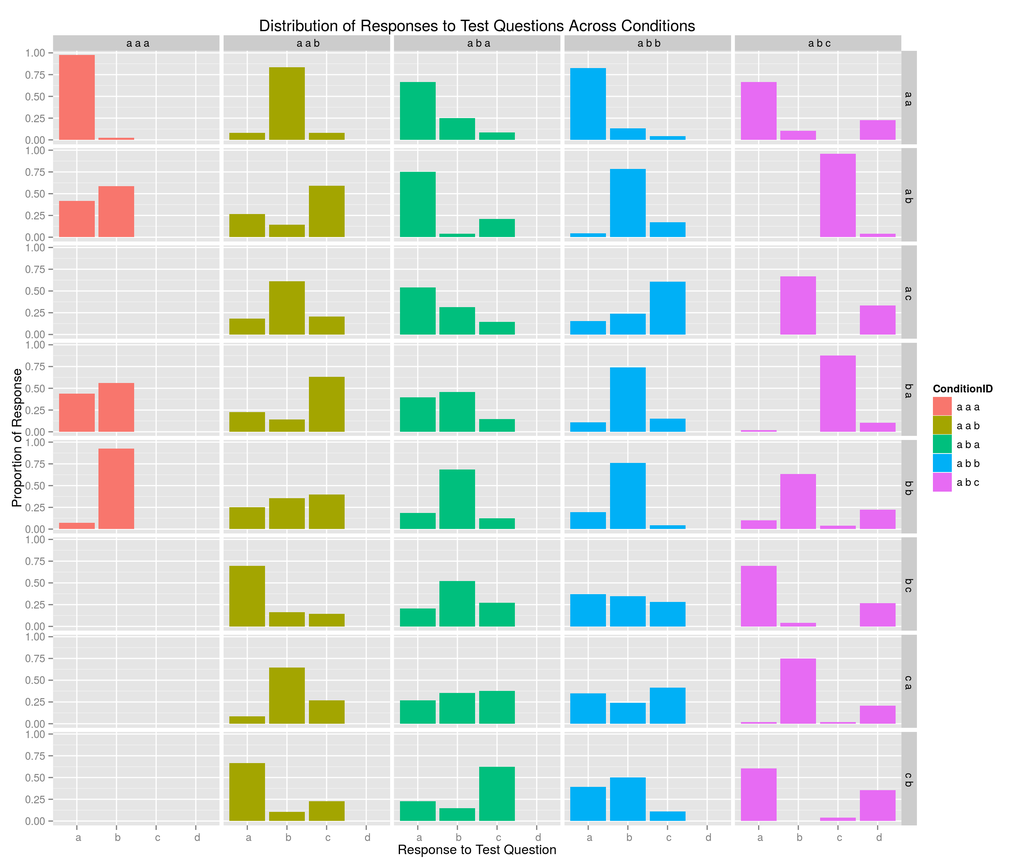

```r
#plot the counts of responses for each condition
# x-axis shows the response given
# y-axis shows the number of participants who gave that response
# faceted by the Condition and the Question. Participants were only given 1 condition.
plt = ggplot(data,aes(x=Response,fill=ConditionID))+
  geom_histogram(aes(y=(..count..)/tapply(..count..,..PANEL..,sum)[..PANEL..]))+
  #geom_histogram()+
  facet_grid(~Question~ConditionID)+
  xlab("Response to Test Question")+
  ylab("Proportion of Response")+
  ggtitle("Distribution of Responses to Test Questions Across Conditions")
plt
```

### Reaction Time Over Trials Between Conditions

#### This may indicate how “easy” each condition is, or possibly hint to the simplicity of hypotheses used.

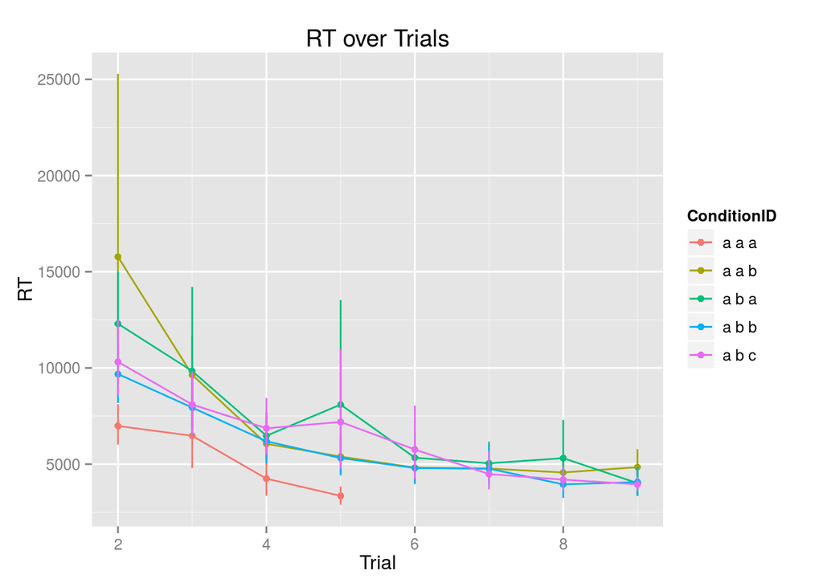

```r
plt=ggplot(data,aes(Trial,RT,color=ConditionID))+
  stat_summary(fun.y=mean,geom="line")+
  stat_summary(fun.data=mean_cl_boot,geom="pointrange")+
  ggtitle("RT over Trials")
plt
```

### Generating proportion tables for each condition

```r
#here we construct the proportion tables for each condition to add to a dataframe for human data from Experiment One
listy = list()

for(val in c(0,1,2,3,4)){
  t = table(data$Response[data$Condition==val],data$Question[data$Condition==val])
  tp = prop.table(t,2)
  frame = as.data.frame(tp)
  frame$cond = val
  listy[[val+1]] = frame
}
humanframe = do.call(rbind,listy)
colnames(humanframe) <- c("Response","Question","Proportion","Condition")
#View(humanframe)
```